# babynames_similarity

James P. Curley

October 17, 2017

In this analysis, we look at the similarity of name distributions over time. It’s clear from previous work on the babynames dataset that names gain and lose popularity over time. Is it possible to classify how similar names are in their distributions?

First lets convert the female data from long format to wide format. This will allow us to perform the clustering analyses we need to do.

```r
#reshape data
babywideF <-
  babynames %>%
  filter(sex=="F") %>%
  select(name, year, n) %>%
  spread(year, n, fill=0)

babywideF <- as.data.frame(babywideF)
rownames(babywideF) <- babywideF$name
babywideF_names<- babywideF$name #save names
babywideF$name<-NULL # remove name var

babywideF[55111:55117,71:74]
```

```
##           1950 1951 1952 1953
## Sherrl       0    0    0    0
## Sherrlyn     8    6    0    0
## Sherrod      0    0    0    0
## Sherrol      0    6    0    7
## Sherron     69   47   55   64
## Sherronda    0    0    0    0
## Sherrone     0    0    0    0
```

```r
babywideF_names[55111:55117]
```

```
## [1] "Sherrl"    "Sherrlyn"  "Sherrod"   "Sherrol"   "Sherron"   "Sherronda"
## [7] "Sherrone"
```

Let’s run a quick exploratory PCA to see roughly how many ‘groups’ of distributions there are:

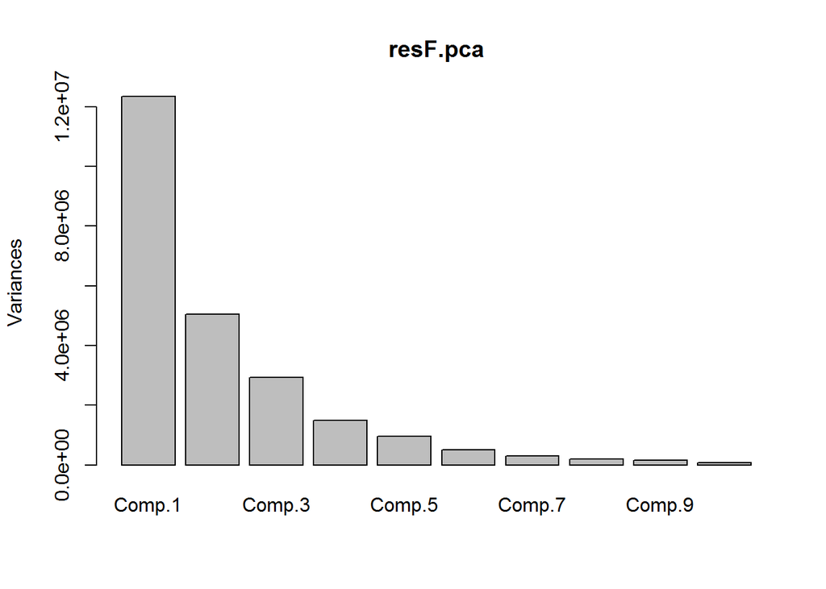

```r
#principal components analysis
resF.pca <- princomp(babywideF)
plot(resF.pca)
```

But, for now, let’s do a k-means clustering using 6 clusters. The plot above seems to suggest that this will account for a lot of the variance. Because k-means clustering assign membership to groups, but these groups may change from run to run of the analysis, I’m setting seed to make the analysis reproducible as an example.

```r
###k-means clustering analysis
set.seed(100)
resF.k <- kmeans(babywideF, 6)
table(resF.k$cluster)
```

```
##
##     1     2     3     4     5     6
##    11 65368    39    19    64   157
```

It’s very clear from the above that most names fall into group 2. This group contains many names that are super rare in the data. Some random examples of these names would be: Alexz, Innocence, and Thuyvy.

We can look at the other groups too. Here are three randomish names from each:

- Group 1: Carol, Mary, Susan
- Group 3: Ann, Frances, Martha
- Group 4: Amy, Kimberly, Sarah
- Group 5: Alexandra, Lauren, Tiffany
- Group 6: Alma, Joann, Wanda

Let’s look at what the distributions for each group look like.

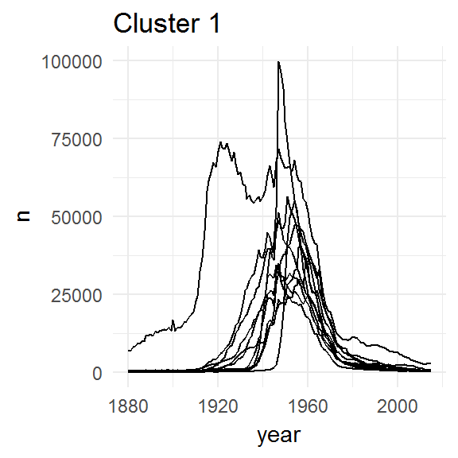

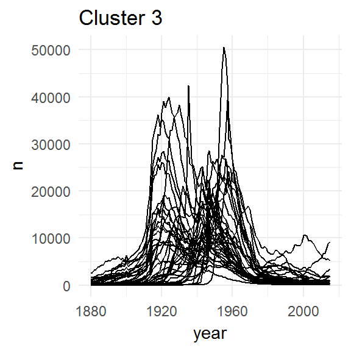

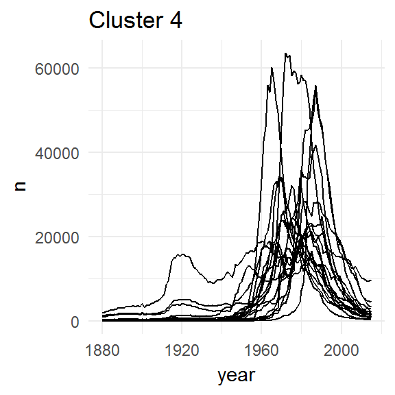

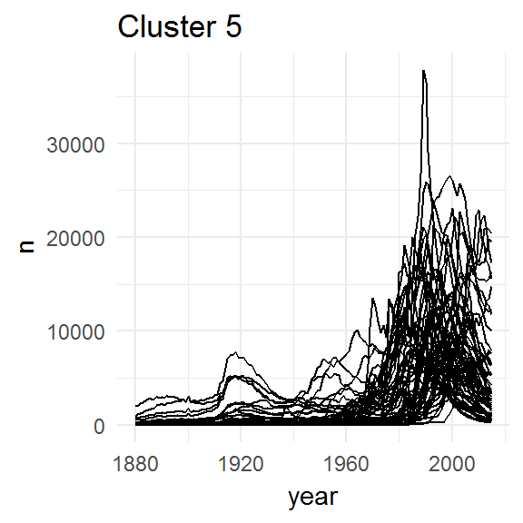

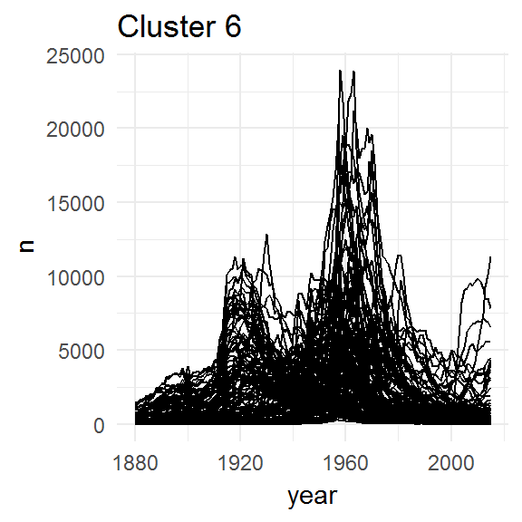

```r
babynames %>%
  filter(sex=="F" & name %in% names(resF.k$cluster[resF.k$cluster==1])) %>%
  ggplot(aes(year, n, group=name)) +
  geom_line() +
  theme_minimal() +
  ggtitle("Cluster 1")

babynames %>%
  filter(sex=="F" & name %in% names(resF.k$cluster[resF.k$cluster==3])) %>%
  ggplot(aes(year, n, group=name)) +
  geom_line() +
  theme_minimal() +
  ggtitle("Cluster 3")

babynames %>%
  filter(sex=="F" & name %in% names(resF.k$cluster[resF.k$cluster==4])) %>%
  ggplot(aes(year, n, group=name)) +
  geom_line() +
  theme_minimal() +
  ggtitle("Cluster 4")

babynames %>%
  filter(sex=="F" & name %in% names(resF.k$cluster[resF.k$cluster==5])) %>%
  ggplot(aes(year, n, group=name)) +
  geom_line() +
  theme_minimal() +
  ggtitle("Cluster 5")

babynames %>%
  filter(sex=="F" & name %in% names(resF.k$cluster[resF.k$cluster==6])) %>%
  ggplot(aes(year, n, group=name)) +
  geom_line() +
  theme_minimal() +
  ggtitle("Cluster 6")
```

We can make some generalizations from these plots. Cluster 1 appears to be super popular names peaking during the baby-boomer period. These names are: Barbara, Carol, Deborah, Donna, Karen, Linda, Mary, Nancy, Patricia, Sandra, Susan. One of these, Mary, doesn’t seem to fit the same distribution as the others precisely as it was also highly popular pre WW2, but because of the number of children called Mary it is put into this group.

After looking at these distributions, I think we could clean this up a little and redo the k-means clustering after excluding those names from cluster 2. We can do that like this:

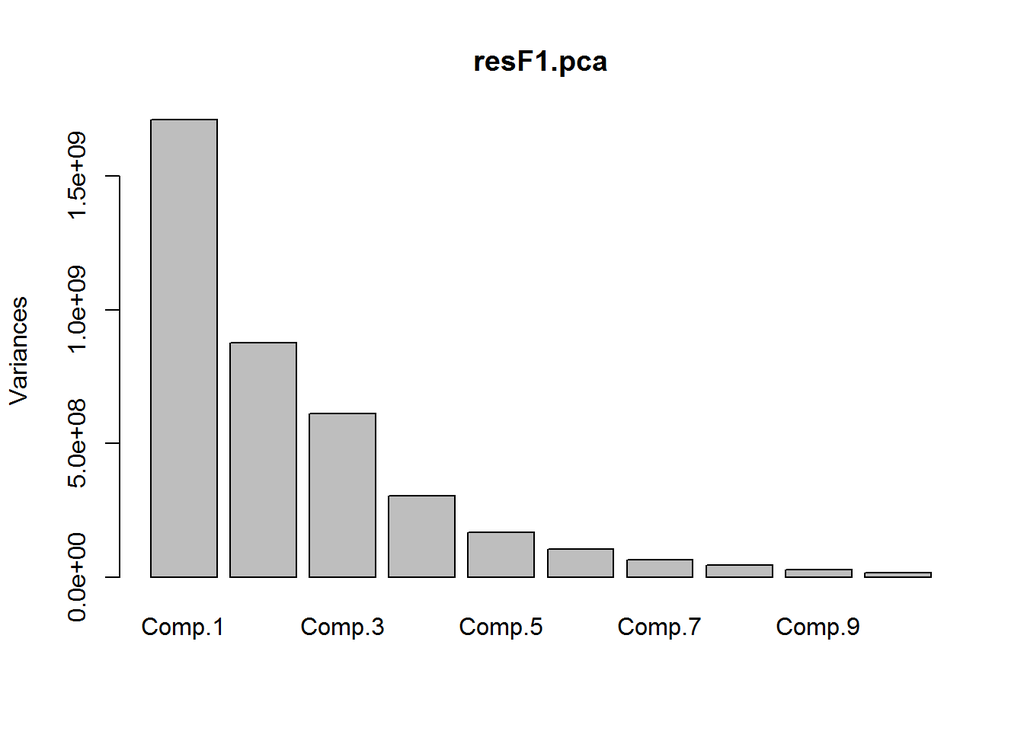

```r
group1x <- names(resF.k$cluster[resF.k$cluster==2])
babywideF1 <- babywideF %>% mutate(id = rownames(.)) %>% filter(!id %in% group1x) %>% as.data.frame()
rownames(babywideF1) <- babywideF1$id
babywideF1$id <- NULL

### principal components analysis - females
resF1.pca <- princomp(babywideF1)
plot(resF1.pca)
```

This time it seems reasonable to pick 7 clusters.

```r
###k-means clustering analysis
set.seed(10)
resF1.k <- kmeans(babywideF1, 7)
table(resF1.k$cluster)
```

```
##
##   1   2   3   4   5   6   7
##  17  17  58   1  17  12 168
```

```r
names(resF1.k$cluster[resF1.k$cluster==4])
```

```
## [1] "Mary"
```

This time, it identifies Mary successfully as being one of a kind. Let’s plot the distributions:

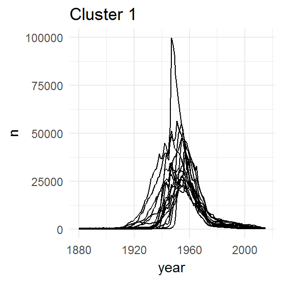

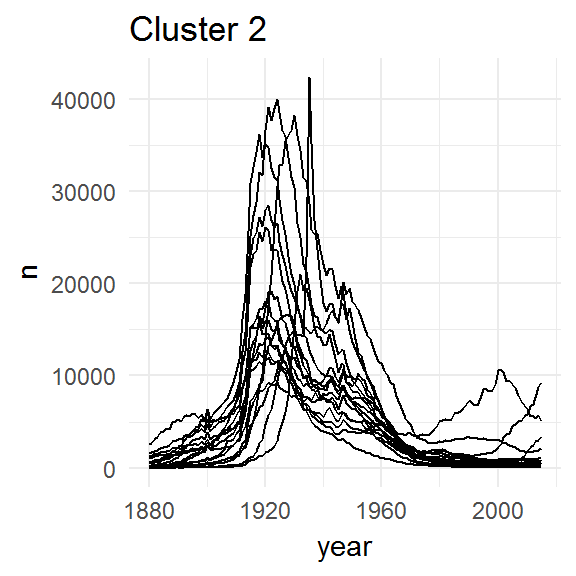

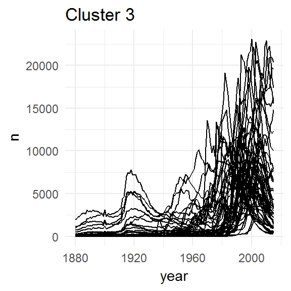

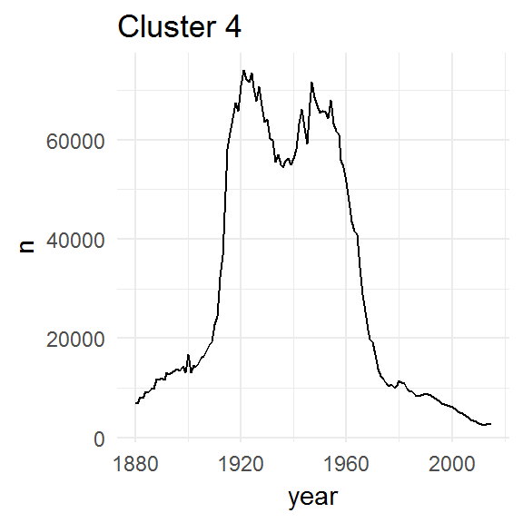

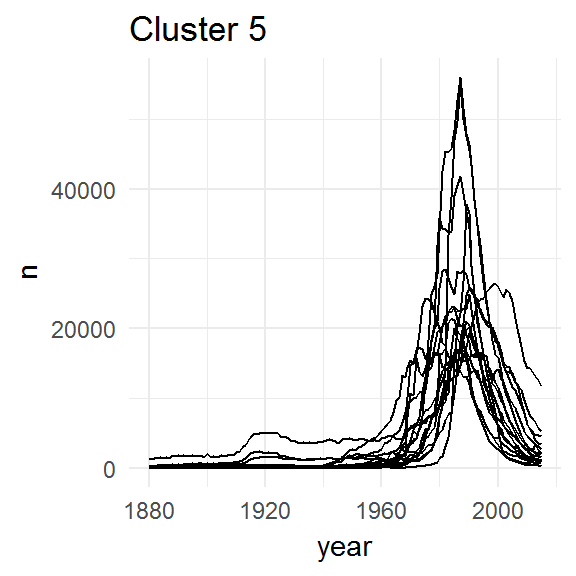

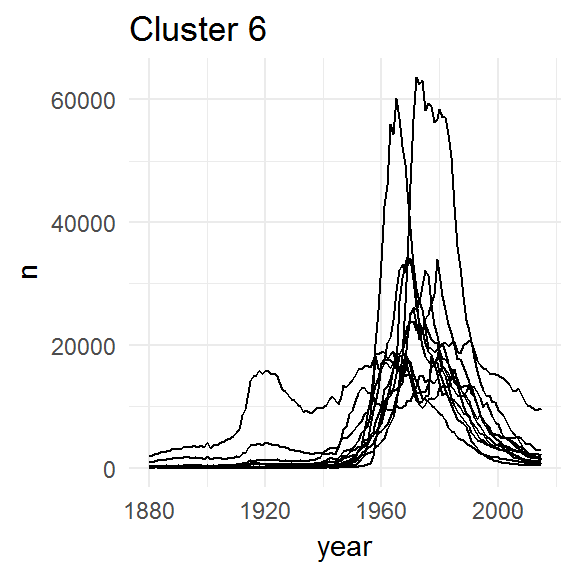

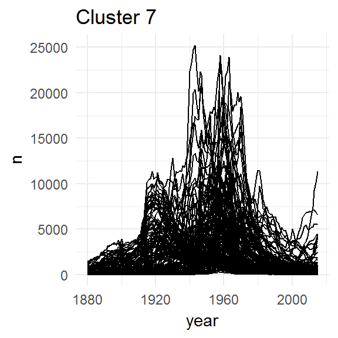

```r
babynames %>%
  filter(sex=="F" & name %in% names(resF1.k$cluster[resF1.k$cluster==1])) %>%
  ggplot(aes(year, n, group=name)) +
  geom_line() +
  theme_minimal() +
  ggtitle("Cluster 1")

babynames %>%
  filter(sex=="F" & name %in% names(resF1.k$cluster[resF1.k$cluster==2])) %>%
  ggplot(aes(year, n, group=name)) +
  geom_line() +
  theme_minimal() +
  ggtitle("Cluster 2")


babynames %>%
  filter(sex=="F" & name %in% names(resF1.k$cluster[resF1.k$cluster==3])) %>%
  ggplot(aes(year, n, group=name)) +
  geom_line() +
  theme_minimal() +
  ggtitle("Cluster 3")

babynames %>%
  filter(sex=="F" & name %in% names(resF1.k$cluster[resF1.k$cluster==4])) %>%
  ggplot(aes(year, n, group=name)) +
  geom_line() +
  theme_minimal() +
  ggtitle("Cluster 4")

babynames %>%
  filter(sex=="F" & name %in% names(resF1.k$cluster[resF1.k$cluster==5])) %>%
  ggplot(aes(year, n, group=name)) +
  geom_line() +
  theme_minimal() +
  ggtitle("Cluster 5")

babynames %>%
  filter(sex=="F" & name %in% names(resF1.k$cluster[resF1.k$cluster==6])) %>%
  ggplot(aes(year, n, group=name)) +
  geom_line() +
  theme_minimal() +
  ggtitle("Cluster 6")

babynames %>%
  filter(sex=="F" & name %in% names(resF1.k$cluster[resF1.k$cluster==7])) %>%
  ggplot(aes(year, n, group=name)) +
  geom_line() +
  theme_minimal() +
  ggtitle("Cluster 7")
```

A summary of the following would be:

**Group 1 - Super popular baby-boomers**  
Barbara, Brenda, Carol, Cynthia, Deborah, Debra, Diane, Donna, Karen, Kathleen, Linda, Nancy, Pamela, Patricia, Sandra, Sharon, Susan

**Group 2 - Pre WW2**  
Alice, Anna, Betty, Doris, Dorothy, Evelyn, Frances, Helen, Jean, Joan, Margaret, Marie, Martha, Mildred, Ruth, Shirley, Virginia

**Group 3 - 2000s**  
Abigail, Alexandra, Alexis, Alicia, Allison, Alyssa, Andrea, Ava, Brianna, Brooke, Caroline, Cassandra, Chelsea, Chloe, Courtney, Crystal, Destiny, Ella, Emma, Erica, Erin, Gabrielle, Grace, Hailey, Haley, Hannah, Isabella, Jamie, Jasmine, Jenna, Jordan, Julia, Kaitlyn, Katelyn, Katherine, Katie, Kayla, Kelsey, Kristen, Leah, Lindsey, Madison, Maria, Melanie, Mia, Morgan, Natalie, Olivia, Paige, Sara, Savannah, Shannon, Shelby, Sophia, Sydney, Taylor, Vanessa, Victoria

**Group 4 - Mary**  
Mary

**Group 5 - 1990s**  
Amanda, Amber, Ashley, Brittany, Christina, Danielle, Emily, Heather, Jessica, Lauren, Megan, Nicole, Rachel, Samantha, Sarah, Stephanie, Tiffany

**Group 7 - The rest - mostly popular in the 60s !**  
Agnes, Alma, Anita, Ann, Anne, Annette, Annie, April, Arlene, Audrey, Beatrice, Becky, Bernice, Bertha, Beth, Beverly, Bonnie, Carla, Carmen, Carole, Carolyn, Carrie, Catherine, Cathy, Charlene, Charlotte, Cheryl, Christine, Cindy, Clara, Claudia, Colleen, Connie, Constance, Dana, Darlene, Dawn, Deanna, Debbie, Delores, Denise, Diana, Dianne, Dolores, Edith, Edna, Eileen, Elaine, Eleanor, Ellen, Elsie, Esther, Ethel, Eva, Florence, Gail, Georgia, Geraldine, Gertrude, Gina, Gladys, Glenda, Gloria, Gwendolyn, Hazel, Heidi, Holly, Ida, Irene, Jackie, Jacqueline, Jane, Janet, Janice, Jeanette, Jeanne, Jessie, Jill, Jo, Joann, Joanne, Josephine, Joy, Joyce, Juanita, Judith, Judy, June, Kathryn, Kathy, Kay, Kim, Kristin, Laurie, Leslie, Lillian, Lillie, Lois, Loretta, Lori, Lorraine, Louise, Lucille, Lucy, Lynn, Marcia, Marian, Marilyn, Marion, Marjorie, Marlene, Marsha, Maureen, Melinda, Michele, Monica, Norma, Patsy, Paula, Pauline, Peggy, Penny, Phyllis, Regina, Renee, Rhonda, Rita, Roberta, Robin, Rosa, Rose, Rosemary, Ruby, Sally, Sheila, Sherri, Sherry, Sheryl, Stacey, Stacy, Sue, Suzanne, Sylvia, Tamara, Tammy, Tanya, Tara, Teresa, Terri, Terry, Thelma, Theresa, Tina, Toni, Tonya, Tracy, Valerie, Vera, Veronica, Vicki, Vickie, Vivian, Wanda, Wendy, Willie, Wilma, Yolanda, Yvonne

#### T-distributed Stochastic Neighbor Embedding.

A method of visualizing similarity/disimilarity in 2D space that I really like is TSNE. We can do that like this:

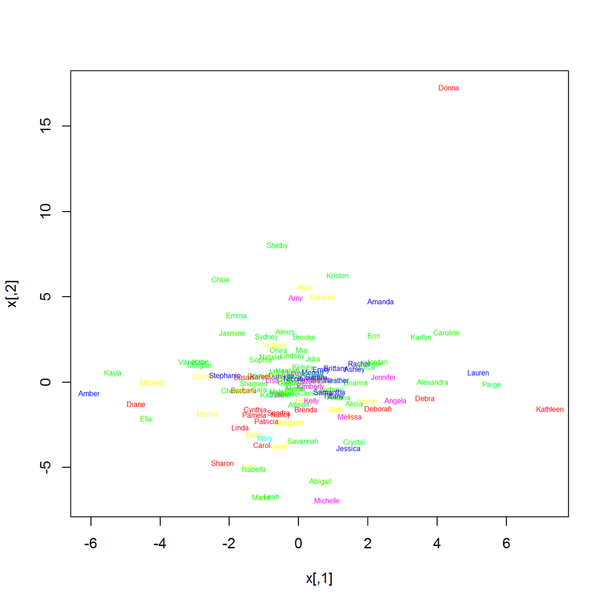

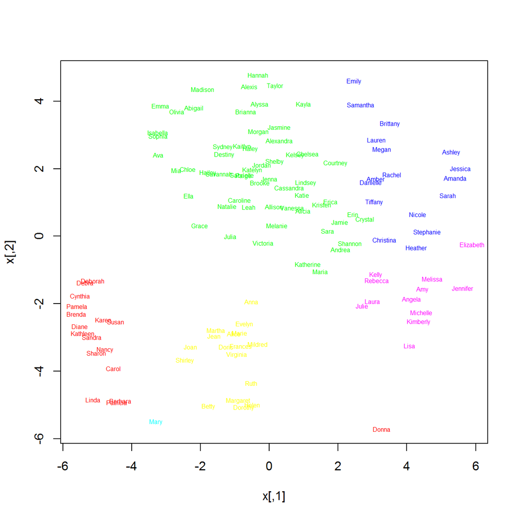

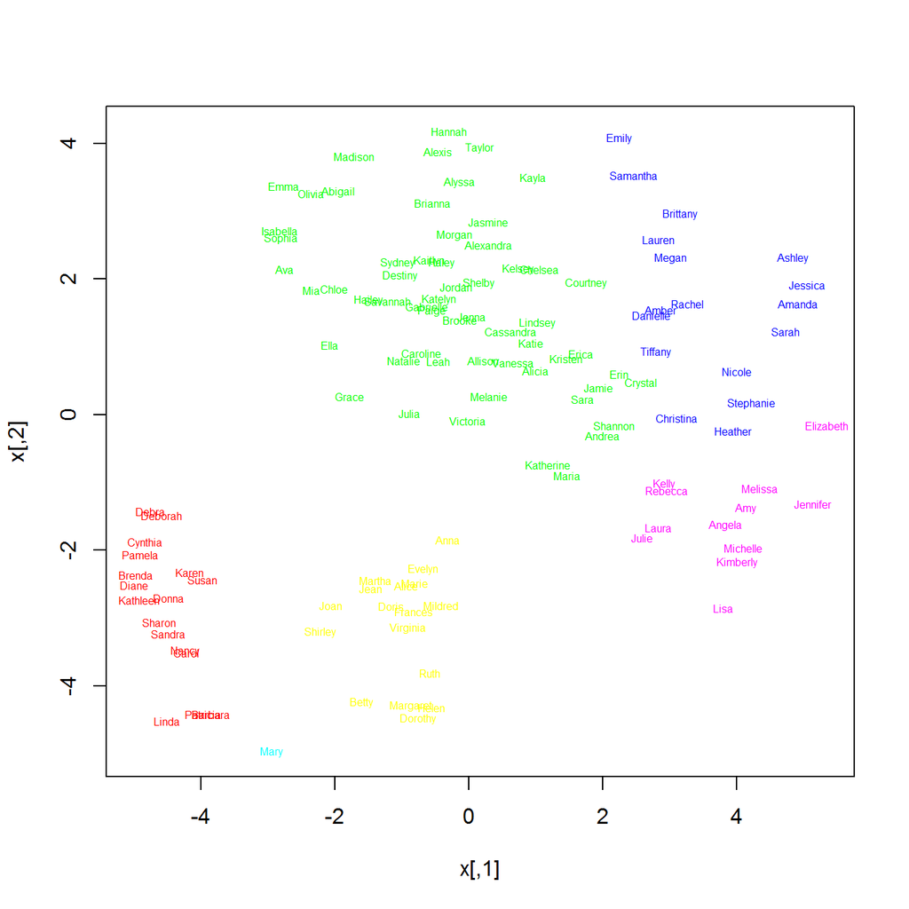

```r
#create some objects to make making a namesdf simpler
group1<-names(resF1.k$cluster[resF1.k$cluster==1])
group2<-names(resF1.k$cluster[resF1.k$cluster==2])
group3<-names(resF1.k$cluster[resF1.k$cluster==3])
group5<-names(resF1.k$cluster[resF1.k$cluster==5])
group6<-names(resF1.k$cluster[resF1.k$cluster==6])
group7<-names(resF1.k$cluster[resF1.k$cluster==7])

#remove group 7
babywideF2 <- babywideF1[!rownames(babywideF1) %in%  group7,]
D <- dist(babywideF2)  #create distance object

# creating dataframe for plotting colors and text on final plot
namesdf <- data.frame(name = c(group1, group2, group3, "Mary", group5, group6),
                      group = c(rep(1, length(group1)), rep(2, length(group2)), rep(3, length(group3)), rep(4, 1),
                                rep(5, length(group5)), rep(6, length(group6)))
)

namesdf %<>% arrange(name) #names in correct order to match rownames of babywideF1

colors = rainbow(6)
names(colors) = unique(namesdf$group)

#define function used in plotting
ecb = function(x,y){ plot(x,t='n'); text(x,labels=rownames(babywideF2), col=colors[namesdf$group], cex=.5) }

#plot
tsne_D = tsne(D, k=2,  epoch_callback = ecb, perplexity=50)
```

From this, I find it interesting that Grace, Ella, Julia, Victoria are towards the boundary with older names. Also, Anna, a pre-WW2 name is moving away from its group. This made me wonder if these may be the names showing the 1920s and 1990s/2000s bumps.

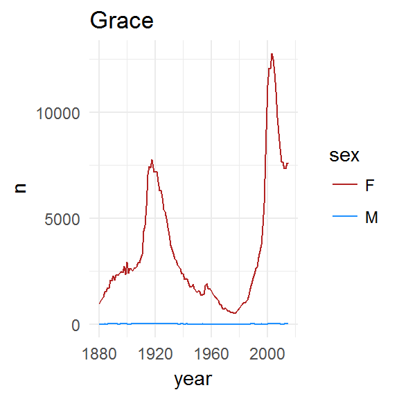

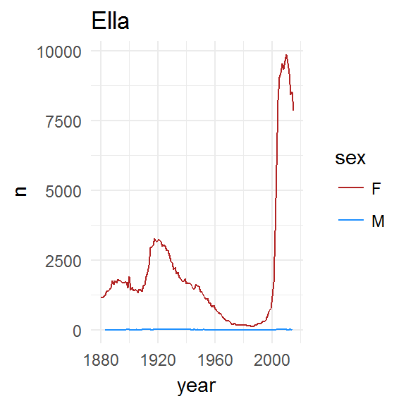

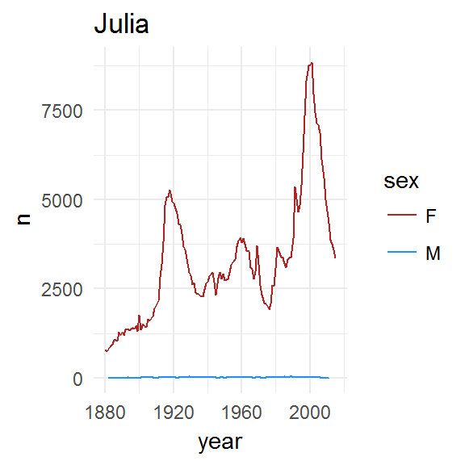

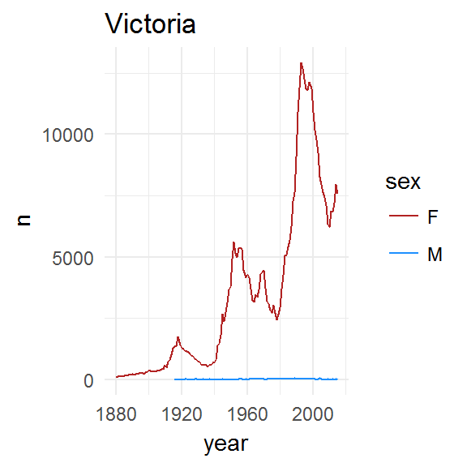

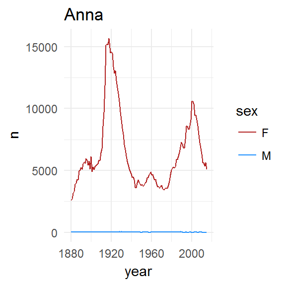

```r
name_plot("Grace") + ggtitle("Grace")
name_plot("Ella") + ggtitle("Ella")
name_plot("Julia") + ggtitle("Julia")
name_plot("Victoria") + ggtitle("Victoria")
name_plot("Anna") + ggtitle("Anna")
```